# Teaching with Sampling

Danny Kaplan

ICOTS Project MOSAIC Workshop; July 12-13, 2014

## The Influence of Technology

Much of what we do is the result of an adaptation to specific technology.

### Example: Computational Instructions

**Technology**: Printing, chalk, pencil, paper

With this physical technology, techniques for teaching were developed.

- Algebraic notation.
- Use of simple quantities: e.g. mean, proportion, standard deviation, …

These established approaches have merits and demerits:

- **plus** We learned things this way, so we’re good at it.
- **plus** They are accepted and considered proper.
- **minus** Students are (broadly speaking) not good at reading or interpreting algebra.
- **minus** Quantities such as the mean are not very engaging.
- **minus** The approach doesn’t scale to the needs of most of today’s users of statistics.
  - Data are too big to use the algebraic formulas.
  - The algebra requires a lot of background to move beyond the very simple.
    - Multiple regression & linear algebra.
  - Many important statistical approaches don’t have algebraic representations. (Example: What’s the formula for fitting a logistic model?)
- **minus** The algebra is a distant and abstract representation of the underlying logic of statistics.

**A New Technology**: Software Packaging up operations so that they can be performed knowing only the interface.

Examples:

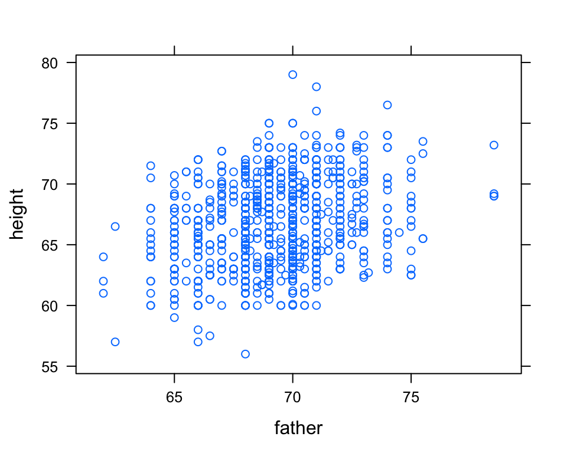

```r
xyplot( height ~ father, data=Galton )
```

```r
t.test( height ~ sex, data=Galton)
```

```
    Welch Two Sample t-test

data:  height by sex
t = -30.66, df = 895, p-value < 2.2e-16
alternative hypothesis: true difference in means is not equal to 0
95 percent confidence interval:
 -5.446 -4.791
sample estimates:
mean in group F mean in group M
          64.11           69.23
```

## A Challenge and an Opportunity

We can easily provide students with just about any possible statistical operation.

- What operations will help students learn statistical thinking?
- What new ways of interacting with students become possible?

## Fundamental Statistical Operations

Nominate candidates, please

- getting a p-value
- regression in two variables
- getting a sampling distribution
- getting a CI
- identifying problems/cleaning data
- interpreting CI

## My Candidates

- Sample
- Describing Relationships
- Randomization
- Repeating stuff

## TenMileRace

Give this command:

```
help(TenMileRace)
```

Focus on these three variables: `net`, `age`, & `sex`

Take two minutes and tell me what you see.

### What the ICOTS Participants Saw and Concluded …

A positive relationship between `net` and `age`:

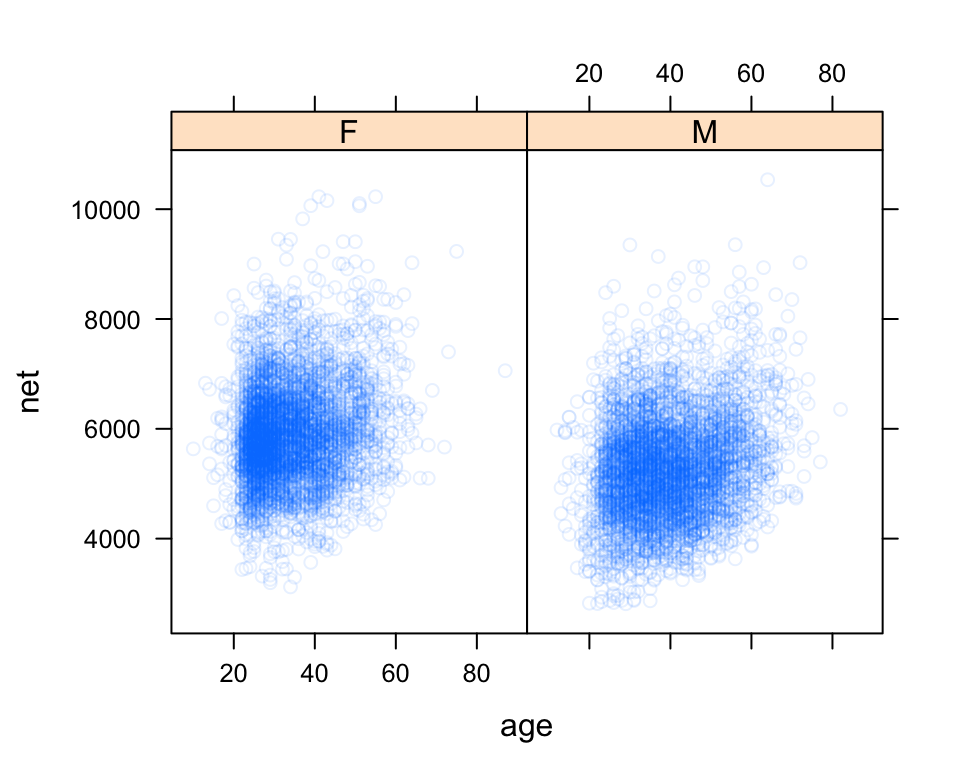

```r
xyplot( net ~ age | sex, data=TenMileRace, alpha=.1)
```

```r
median( net ~ sex, data=TenMileRace)
```

```
   F    M
5843 5236
```

```r
tally(~ sex, data=TenMileRace, format="proportion")
```

```
     F      M
0.5008 0.4992
```

### All Together Now …

Let’s have everyone do this same analysis on the same data.

- Do different people get different results? Explain why or why not.

### A Different Use for These Data

Imagine that you are studying runners’ performance. You need to collect some data.

You can’t practically study every runner, so you will take a sample.

## The Most Important Template

## **goal ( y ~ x , data = mydata )**

We’ve used this template to do calculations on data. But what are the data?

One way to think of it …

## **goal ( y ~ x , data = sample(thepopulation) )**

## Sampling as an Operation

The mosaic `sample()` function takes a [simple random sample](http://en.wikipedia.org/wiki/Simple_random_sample).

Example:

```r
sample(Galton, size=3)
```

```
    family father mother sex height nkids orig.ids
215     56     71     62   M   70.5     5      215
279     70     70     65   M   65.0     5      279
312     76     70     64   M   66.0     7      312
```

You try it. Did you get the same result?

## Sampling Produces Variation

Let’s look at the proportion of runners of each sex in a sample of size $n=100$.

```r
tally( ~ sex, format = 'proportion',
       data = sample(TenMileRace, size = 100) )
```

```
   F    M
0.46 0.54
```

Did you get the same result? Why or why not?

Let’s look at your results.

- Ask a couple of students
- Ask others who have much larger or smaller results.
- Beep when I’m pointing near your answer

## How about $n=400$

```r
tally( ~ sex, format = 'proportion',
       data = sample(TenMileRace, size = 400) )
```

```
     F      M
0.5175 0.4825
```

- Beep when I’m pointing near your answer

## Now, $n=1600$

```r
tally( ~ sex, format = 'proportion',
       data = sample(TenMileRace, size = 1600) )
```

```
    F     M
0.515 0.485
```

- Beep when I’m pointing near your answer

## What’s the Pattern?

What is the pattern in the spread of answers?

## If you wanted to do it all yourself

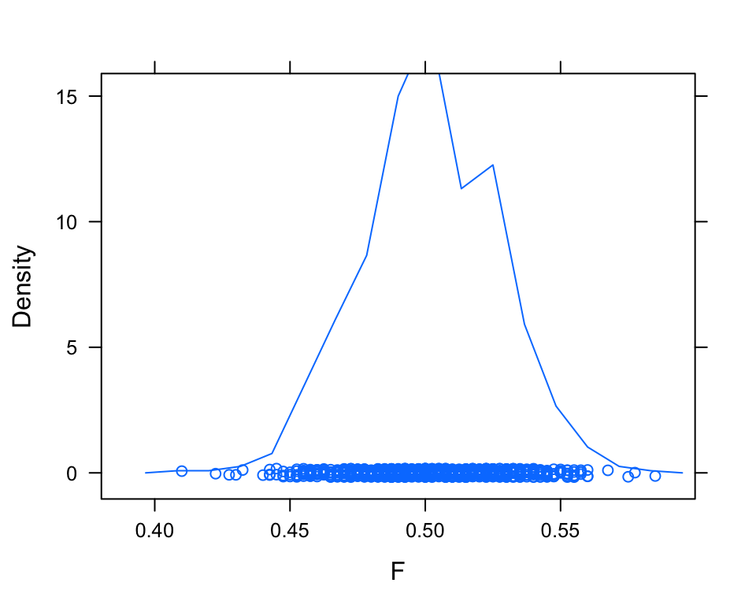

```r
Trials <- do(1000)* tally( ~ sex, format = 'proportion',
       data = sample(TenMileRace, size = 400) )
freqpolygon( ~ F, data = Trials )
```

Tell me how to compute the standard error.

Do this calculation for sample sizes $n=$100, 400, 1600 and tell me the standard error:

## Schematic of the Sampling Distribution

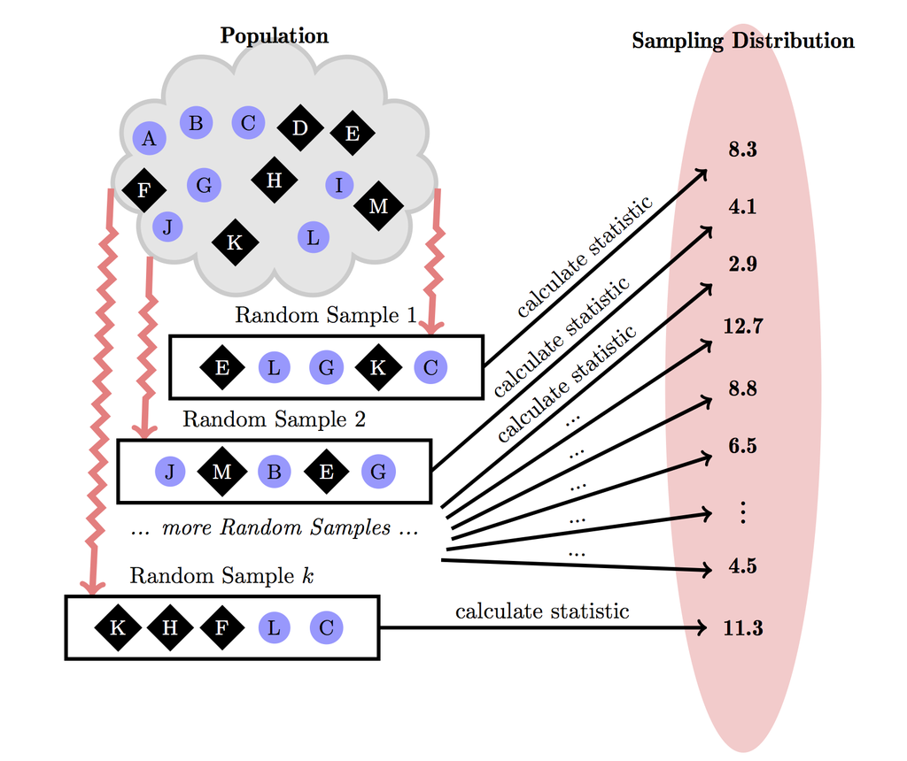

## Back toward the Real World

We don’t often have the chance to get multiple samples from our population, like the 1000 samples taken above.

- Samples are expensive, time consuming, and potentially destructive.
- If we could take many samples, we would be well to combine them into one larger sample.

## Resampling Distribution

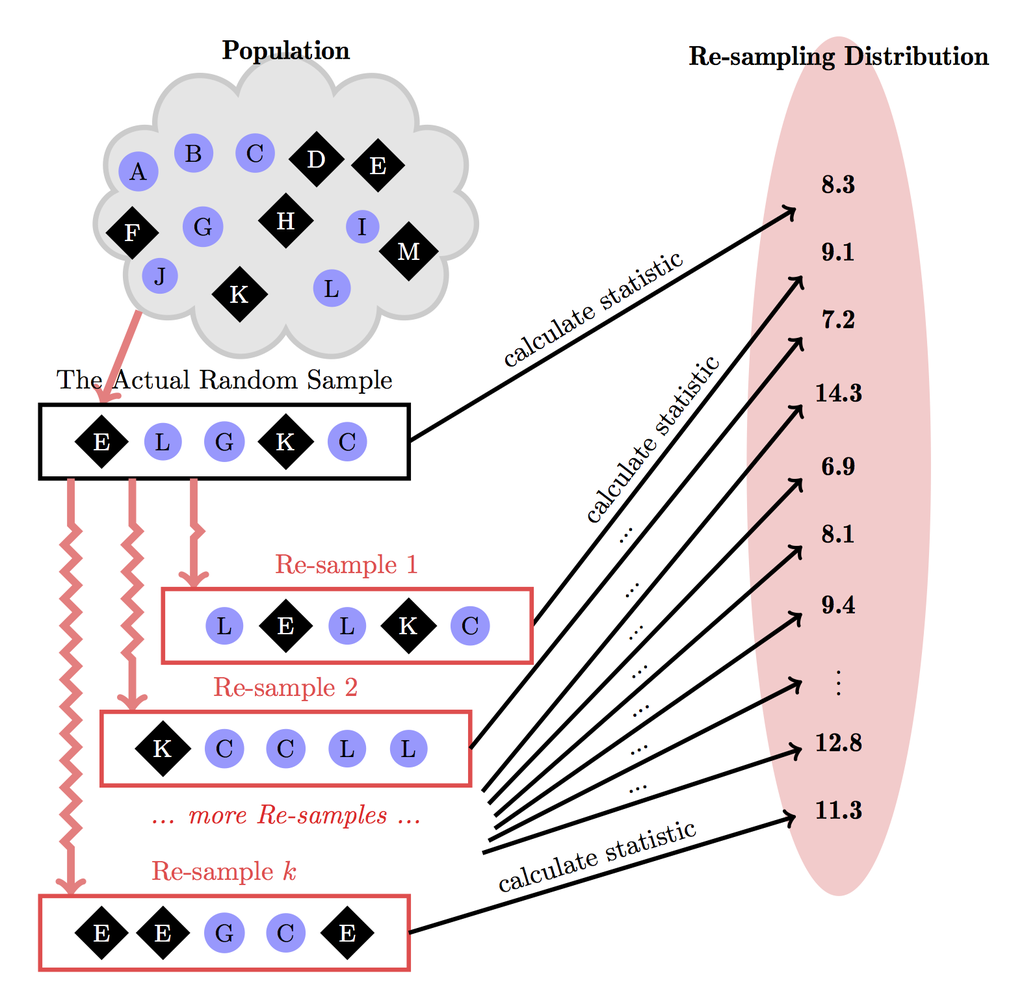

## The resample() function

As an example, start with a very small data set:

```r
GaltonSmall <- sample(Galton, size = 5)
GaltonSmall
```

```
    family father mother sex height nkids orig.ids
734    168   67.0   63.5   M   65.5     8      734
331     79   70.5   64.0   F   65.0     8      331
402     96   70.0   58.0   F   66.0     5      402
547    126   69.0   60.0   M   66.0     4      547
347     83   70.0   63.7   M   67.0     8      347
```

What’s going on with `resample()`?

```r
resample( GaltonSmall )
```

```
      family father mother sex height nkids orig.ids
402       96     70   58.0   F   66.0     5        3
547      126     69   60.0   M   66.0     4        4
547.1    126     69   60.0   M   66.0     4        4
734      168     67   63.5   M   65.5     8        1
347       83     70   63.7   M   67.0     8        5
```

You do it several times.

## Contest

Can anyone get a resample with two or fewer of the original cases?

How about the same case repeated five times?

## The Re-Sampling Distribution of the Mean (or whatever)

```r
Trials <- do(1000) * mean( ~ height, data = resample(Galton) )
# Now find the standard error
```

### Example: Do Husbands and Wives have Related Heights

Use the correlation coefficient: `cor(father ~ mother, data=)`

What’s your answer?

#### Technical Note:

The case in `Galton` is a child. We should look at the relationship between husband and wife based on families. An instructor might want to give students the commands to do this, without having the student try to construct them.

```r
ByFamily <- Galton %>% group_by(family) %>% sample_n(size=1)
```

Use `ByFamily` to find the correlation and it’s resampling distribution.

### Example: Do Sons and Fathers have Related Heights

This is the problem Galton studied:

```r
Boys <- subset(Galton, sex=='M')
Trials2 <- do(1000)*cor( father ~ height, data = resample(Boys))
```

## Hypothesis Testing

Use `shuffle()`.

What’s a typical p-value when the Null Hypothesis is right?

```r
NullPvalues <- do(1000)*t.test( height ~ shuffle(sex), data=Galton )$p.value
```

## The Modeling Template

Let’s teach the variety of “tests” using one framework that they all have in common. So put the zoo of tests aside for a moment — the t-tests, the p-tests, the tests of r and R^2, chi-squared, etc. Instead, point out that they are all varieties of animal.

The common framework is the linear model: a response variable broken down by one or more explanatory variables.

- Two-sample t-test

```r
mod1 <- lm( height ~ sex, data=Galton )
summary(mod1)
```

```
Call:
lm(formula = height ~ sex, data = Galton)

Residuals:
   Min     1Q Median     3Q    Max
 -9.23  -1.61  -0.11   1.77   9.77

Coefficients:
            Estimate Std. Error t value Pr(>|t|)
(Intercept)   64.110      0.121   531.7   <2e-16 ***
sexM           5.119      0.168    30.6   <2e-16 ***
---
Signif. codes:  0 '***' 0.001 '**' 0.01 '*' 0.05 '.' 0.1 ' ' 1

Residual standard error: 2.51 on 896 degrees of freedom
Multiple R-squared:  0.51,  Adjusted R-squared:  0.51
F-statistic:  933 on 1 and 896 DF,  p-value: <2e-16
```

- Single proportions

```r
mod2 <- lm( sex=='F' ~ 1, data=TenMileRace)
confint(mod2)
```

```
             2.5 % 97.5 %
(Intercept) 0.4903 0.5114
```

```r
summary( mod2 )
```

```
Call:
lm(formula = sex == "F" ~ 1, data = TenMileRace)

Residuals:
   Min     1Q Median     3Q    Max
-0.501 -0.501  0.499  0.499  0.499

Coefficients:
            Estimate Std. Error t value Pr(>|t|)
(Intercept)  0.50081    0.00538    93.1   <2e-16 ***
---
Signif. codes:  0 '***' 0.001 '**' 0.01 '*' 0.05 '.' 0.1 ' ' 1

Residual standard error: 0.5 on 8635 degrees of freedom
```

The answer is exactly the same as you would get from the familiar formula: $\sqrt{\hat{p} (1-\hat{p})/n$:

```r
sqrt( .5008*(1-.5008)/nrow(TenMileRace))
```

```
[1] 0.00538
```

- Difference of two proportions: Here, we’ll look at whether the fraction of females in the workforce is the same for unionized and non-union workers (in 1985, per the `CPS85` data in `mosaic`).

  ```r
  mod3 <- lm( sex=="F" ~ union, data=CPS85)
  confint(mod3)
  ```

  ```
                2.5 %   97.5 %
  (Intercept)  0.4492  0.54171
  unionUnion  -0.3129 -0.09462
  ```

  ```r
  summary(mod3)
  ```

  ```
  Call:
  lm(formula = sex == "F" ~ union, data = CPS85)

  Residuals:
     Min     1Q Median     3Q    Max
  -0.495 -0.495 -0.292  0.505  0.708

  Coefficients:
              Estimate Std. Error t value Pr(>|t|)
  (Intercept)   0.4954     0.0236   21.03  < 2e-16 ***
  unionUnion   -0.2038     0.0556   -3.67  0.00027 ***
  ---
  Signif. codes:  0 '***' 0.001 '**' 0.01 '*' 0.05 '.' 0.1 ' ' 1

  Residual standard error: 0.493 on 532 degrees of freedom
  Multiple R-squared:  0.0247,    Adjusted R-squared:  0.0228
  F-statistic: 13.4 on 1 and 532 DF,  p-value: 0.00027
  ```

  Yes, women appear in a much smaller proportion among unionized workers (in 1985).
- One sample t test Is the height of Galton’s subjects different from 65 inches? `1` stands for a variable that is the same for every case, as if there were a column of ones in the data frame.

  ```r
  mod4 <- lm( height-65 ~ 1, data = Galton)
  confint( mod4 )
  ```

  ```
              2.5 % 97.5 %
  (Intercept) 1.526  1.995
  ```

  ```r
  summary(mod4)
  ```

  ```
  Call:
  lm(formula = height - 65 ~ 1, data = Galton)

  Residuals:
      Min      1Q  Median      3Q     Max
  -10.761  -2.761  -0.261   2.939  12.239

  Coefficients:
              Estimate Std. Error t value Pr(>|t|)
  (Intercept)     1.76       0.12    14.7   <2e-16 ***
  ---
  Signif. codes:  0 '***' 0.001 '**' 0.01 '*' 0.05 '.' 0.1 ' ' 1

  Residual standard error: 3.58 on 897 degrees of freedom
  ```

- Multiple regression

  ```r
  mod5 <- lm( height ~ father + mother + sex,
          data = Galton)
  confint(mod5)
  ```

  ```
               2.5 %  97.5 %
  (Intercept) 9.9535 20.7360
  father      0.3487  0.4633
  mother      0.2601  0.3829
  sexM        4.9433  5.5086
  ```

  ```r
  summary(mod5)
  ```

  ```
  Call:
  lm(formula = height ~ father + mother + sex, data = Galton)

  Residuals:
     Min     1Q Median     3Q    Max
  -9.523 -1.440  0.117  1.473  9.114

  Coefficients:
              Estimate Std. Error t value Pr(>|t|)
  (Intercept)  15.3448     2.7470    5.59  3.1e-08 ***
  father        0.4060     0.0292   13.90  < 2e-16 ***
  mother        0.3215     0.0313   10.28  < 2e-16 ***
  sexM          5.2260     0.1440   36.29  < 2e-16 ***
  ---
  Signif. codes:  0 '***' 0.001 '**' 0.01 '*' 0.05 '.' 0.1 ' ' 1

  Residual standard error: 2.15 on 894 degrees of freedom
  Multiple R-squared:  0.64,  Adjusted R-squared:  0.638
  F-statistic:  529 on 3 and 894 DF,  p-value: <2e-16
  ```

- Simple regression

  ```r
  mod6 <- lm( height ~ father, data=Galton )
  summary(mod6)
  ```

  ```
  Call:
  lm(formula = height ~ father, data = Galton)

  Residuals:
      Min      1Q  Median      3Q     Max
  -10.268  -2.669  -0.209   2.634  11.933

  Coefficients:
              Estimate Std. Error t value Pr(>|t|)
  (Intercept)  39.1104     3.2271   12.12   <2e-16 ***
  father        0.3994     0.0466    8.57   <2e-16 ***
  ---
  Signif. codes:  0 '***' 0.001 '**' 0.01 '*' 0.05 '.' 0.1 ' ' 1

  Residual standard error: 3.45 on 896 degrees of freedom
  Multiple R-squared:  0.0758,    Adjusted R-squared:  0.0748
  F-statistic: 73.5 on 1 and 896 DF,  p-value: <2e-16
  ```

- One-way ANOVA Here we look at the wage in different sectors of the economy.

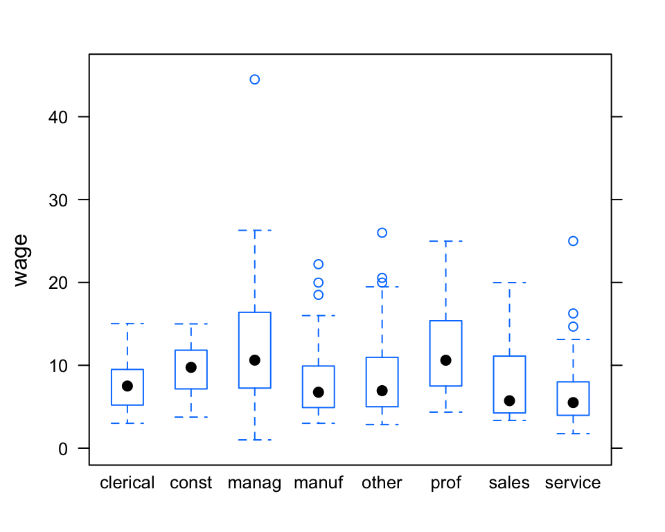

  ```r
  bwplot( wage ~ sector, data=CPS85 )
  ```

  ```r
  mod7 <- lm( wage ~ sector, data=CPS85 )
  anova(mod7)
  ```

  ```
  Analysis of Variance Table

  Response: wage
             Df Sum Sq Mean Sq F value Pr(>F)
  sector      7   2572     367    16.8 <2e-16 ***
  Residuals 526  11505      22
  ---
  Signif. codes:  0 '***' 0.001 '**' 0.01 '*' 0.05 '.' 0.1 ' ' 1
  ```

- Two-way ANOVA

  ```r
  mod8 <- lm( wage ~ sex + union, data = CPS85)
  anova(mod8)
  ```

  ```
  Analysis of Variance Table

  Response: wage
             Df Sum Sq Mean Sq F value  Pr(>F)
  sex         1    594     594   23.81 1.4e-06 ***
  union       1    242     242    9.71  0.0019 **
  Residuals 531  13241      25
  ---
  Signif. codes:  0 '***' 0.001 '**' 0.01 '*' 0.05 '.' 0.1 ' ' 1
  ```

- Two-way ANOVA with interaction

  ```r
  mod9 <- lm( wage ~ sex + union + sex:union, data = CPS85)
  anova(mod9)
  ```

  ```
  Analysis of Variance Table

  Response: wage
             Df Sum Sq Mean Sq F value  Pr(>F)
  sex         1    594     594   23.77 1.4e-06 ***
  union       1    242     242    9.69   0.002 **
  sex:union   1      1       1    0.04   0.833
  Residuals 530  13240      25
  ---
  Signif. codes:  0 '***' 0.001 '**' 0.01 '*' 0.05 '.' 0.1 ' ' 1
  ```

- Analysis of covariance

  ```r
  mod10 <- lm( wage ~ age + sex, data=CPS85)
  summary(mod10)
  ```

  ```
  Call:
  lm(formula = wage ~ age + sex, data = CPS85)

  Residuals:
     Min     1Q Median     3Q    Max
   -9.51  -3.43  -1.00   2.31  38.06

  Coefficients:
              Estimate Std. Error t value Pr(>|t|)
  (Intercept)   4.6542     0.7610    6.12  1.9e-09 ***
  age           0.0852     0.0183    4.66  4.1e-06 ***
  sexM          2.2747     0.4303    5.29  1.8e-07 ***
  ---
  Signif. codes:  0 '***' 0.001 '**' 0.01 '*' 0.05 '.' 0.1 ' ' 1

  Residual standard error: 4.94 on 531 degrees of freedom
  Multiple R-squared:  0.0797,    Adjusted R-squared:  0.0763
  F-statistic:   23 on 2 and 531 DF,  p-value: 2.61e-10
  ```

### Note about proportions …

`lm()` is a perfectly good way to calculate the differences in proportions among discrete groups.

```r
mod11 <- glm( sex=='F' ~ age + educ + union, data=CPS85)
summary(mod11)
```

```
Call:
glm(formula = sex == "F" ~ age + educ + union, data = CPS85)

Deviance Residuals:
   Min      1Q  Median      3Q     Max
-0.618  -0.471  -0.263   0.511   0.783

Coefficients:
            Estimate Std. Error t value Pr(>|t|)
(Intercept)  0.30667    0.13673    2.24    0.025 *
age          0.00431    0.00185    2.33    0.020 *
educ         0.00252    0.00823    0.31    0.760
unionUnion  -0.21907    0.05578   -3.93  9.7e-05 ***
---
Signif. codes:  0 '***' 0.001 '**' 0.01 '*' 0.05 '.' 0.1 ' ' 1

(Dispersion parameter for gaussian family taken to be 0.2415)

    Null deviance: 132.59  on 533  degrees of freedom
Residual deviance: 128.01  on 530  degrees of freedom
AIC: 762.7

Number of Fisher Scoring iterations: 2
```

1. A positive coefficient means “higher proportion.” A negative coefficient means “lower proportion.”
2. The proportion itself is easily graphed using the function technique.

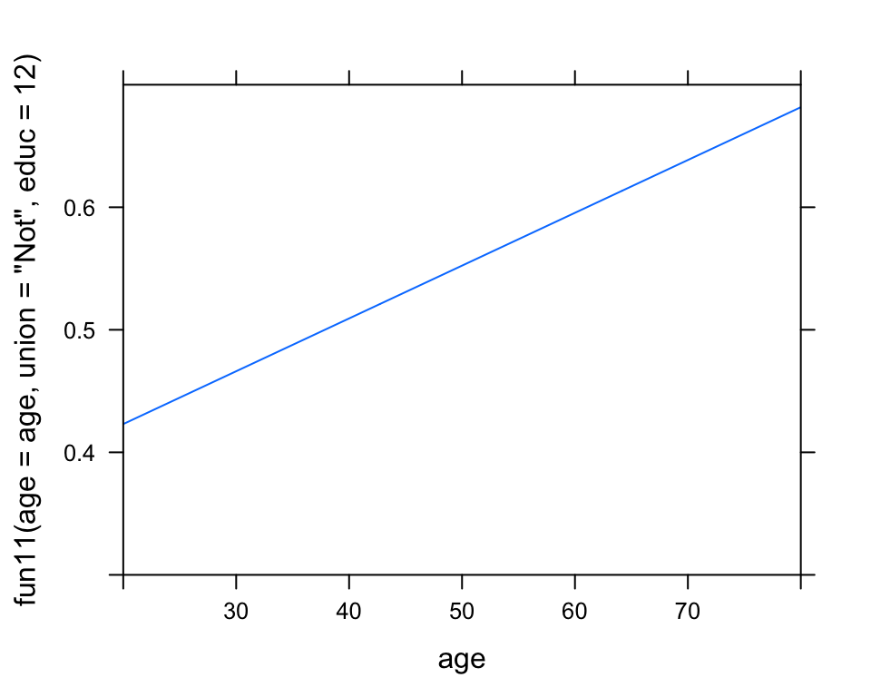

```r
fun11 <- makeFun(mod11)
plotFun( fun11( age=age, union='Not',educ=12)~age,
         age.lim=range(20,80), ylim=range(.3,.7))
```

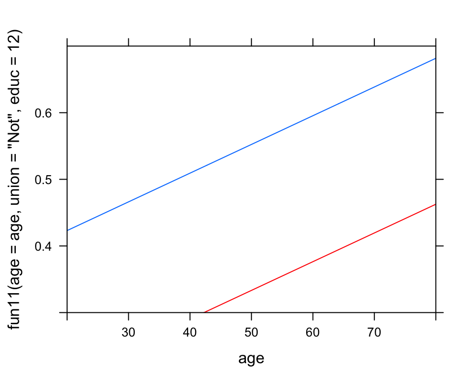

```r
plotFun( fun11( age=age, union='Union',educ=12)~age,
         add=TRUE, col='red' )
```